© Bản quyền thuộc về Quantopian Inc.  
© Bản quyền sửa đổi thuộc về AI Cafe¹  
Giấy phép [Creative Commons Attribution 4.0](https://creativecommons.org/licenses/by/4.0/legalcode).  
[Khuyến cáo](https://aicafe.one/khuyen-cao/)

# Phân tán rủi ro

By Maxwell Margenot and Delaney Granizo-Mackenzie

Edited by AI Cafe¹

Khi giao dịch, việc đa dạng hóa rủi ro là rất quan trọng. Bằng cách tập trung các vị trí của bạn chỉ vào một vài tài sản, bạn có thể bị ảnh hưởng tiêu cực bởi những rủi ro của chúng. Bài giảng này được thiết kế để chỉ ra cách mà việc đa dạng hóa danh mục đầu tư của bạn có thể dẫn đến một hồ sơ rủi ro tổng thể thấp hơn.

```python
import numpy as np
import matplotlib.pyplot as plt
```

## Trực giác

Giả sử bạn đã học cách đếm bài trong trò chơi Blackjack, và hầu hết các sòng bạc sẽ đuổi bạn ra ngoài nếu bạn bị phát hiện, nhưng điều này sẽ mang lại cho bạn một lợi thế khoảng [1% so với nhà cái](https://en.wikipedia.org/wiki/Card_counting). Nếu bạn bước vào sòng bạc với $10,000 để đặt cược, rõ ràng sẽ là điên rồ nếu đặt toàn bộ số tiền vào một trò chơi. Mặc dù bạn có 51% cơ hội thắng trò chơi đó, nhà cái vẫn có 49% cơ hội. Kết quả mong đợi là bạn sẽ thắng trò chơi, nhưng độ biến động thì vô cùng cao.

Giả sử bạn chia số tiền của mình ra 100 bàn khác nhau. Đây được gọi là đặt cược độc lập, vì kết quả của một bàn không ảnh hưởng đến các bàn khác. Độ biến động của bạn sẽ giảm khi bạn thực hiện nhiều lần cược hơn. Bạn vẫn mong đợi thắng 51% số bàn, nhưng khả năng thua lỗ sẽ giảm đi rất nhiều. Hãy cùng xem điều này trong thực tế.

### Mô phỏng các trò chơi Blackjack

Mỗi trò chơi sẽ được thắng với xác suất 51%. Chúng ta có thể mô phỏng điều này bằng cách sử dụng phân phối nhị thức, được tham số hóa với số lần thử nghiệm mà chúng ta thực hiện (trò chơi) và xác suất thành công của mỗi lần thử.

Đầu tiên, chúng ta sẽ mô phỏng 1000 bàn khác nhau, trong đó bạn bước vào sòng bạc và chơi một trò chơi.

```python
universes = 1000

results = np.zeros((universes, 1))
for i in range(universes):
    results[i] = np.random.binomial(n=1, p=0.51)
```

Bây giờ hãy kiểm tra giá trị trung bình và độ lệch chuẩn của các kết quả. Chúng ta thấy rằng vì có rất nhiều số 0 và số 1, và không có gì ở giữa, độ lệch chuẩn rất cao. Điều này có nghĩa là bạn nên kỳ vọng thắng khoảng một nửa ván chơi, với các kết quả khả thi được phân phối gần như đều giữa thua và thắng. Vì bạn đã chơi quá ít ván, bạn đã không cho thời gian cho lợi thế của mình phát huy tác dụng.

```python
np.mean(results), np.std(results)
```

```
(np.float64(0.499), np.float64(0.49999899999899994))
```

Bây giờ hãy mô phỏng 1000 bàn trong đó bạn bước vào sòng bạc và chơi 100 ván.

```python
universes = 1000

results = np.zeros((universes, 1))
for i in range(universes):
    results[i] = np.random.binomial(n=100, p=0.51)

np.mean(results), np.std(results)
```

```
(np.float64(51.019), np.float64(4.993459622346014))
```

Bây giờ chúng ta thấy rằng kết quả trung bình gần với 51 ván thắng hơn, với độ lệch chuẩn nhỏ hơn. Chúng ta thấy rằng bạn có thể vẫn chưa an toàn, vì lợi thế kỳ vọng của bạn chỉ là một ván, trong khi độ lệch chuẩn lại là nhiều ván. Điều này cho thấy bạn có thể hợp lý mong đợi thua nhiều ván hơn thắng. Cuối cùng, hãy thử với 10_000 ván.

```python
universes = 1000

results = np.zeros((universes, 1))
for i in range(universes):
    results[i] = np.random.binomial(n=10_000, p=0.51)

np.mean(results), np.std(results)
```

```
(np.float64(5099.561), np.float64(52.337159638253205))
```

Trong trường hợp này, chúng ta an toàn hơn nhiều, vì lợi thế dự kiến là 100 ván.

LƯU Ý: Có một điểm tinh tế rằng không phải lúc nào cũng hợp lệ khi sử dụng độ lệch chuẩn, vì phân phối dữ liệu cơ sở trong trường hợp này không phải là phân phối chuẩn. Chúng tôi sử dụng nó ở đây vì độ lệch chuẩn là chỉ số đo lường sự biến động được sử dụng trong tài chính, và nó vẫn phản ánh mức độ 'phân tán' có trong dữ liệu. Hãy cẩn thận không lạm dụng độ lệch chuẩn trong thực tiễn bằng cách giả định rằng dữ liệu cơ sở là phân phối chuẩn.

## Mở rộng đến Lý thuyết Danh mục Đầu tư

Nguyên tắc giống hệt như vậy tồn tại trong lý thuyết danh mục đầu tư. Nếu bạn nghĩ rằng bạn có lợi thế hơn thị trường trong việc chọn cổ phiếu sẽ tăng hoặc giảm, bạn nên cố gắng thực hiện càng nhiều lần cược độc lập càng tốt. Điều này có thể đạt được bằng cách đầu tư vào càng nhiều tài sản không tương quan càng tốt. Hãy cùng xem xét một ví dụ.

Hãy nhớ rằng trong tài chính, độ biến động được đo bằng độ lệch chuẩn của một chuỗi thời gian, và mức độ rủi ro tương lai của một danh mục đầu tư được ước lượng bằng độ biến động trong quá khứ của danh mục đầu tư.

### Trường hợp 1: Đầu tư vào một vài tài sản

Hãy mô phỏng một số tài sản bằng cách lấy mẫu từ phân phối chuẩn.

LƯU Ý: Trong thực tế, lợi suất của các tài sản tài chính thực sự hiếm khi phân phối theo kiểu chuẩn, vì vậy đây không phải là một giả định tốt. Tuy nhiên, ở đây chúng ta có thể chấp nhận điều đó để truyền đạt thông điệp của mình vì chúng ta chỉ quan tâm đến mối tương quan và mức độ biến động.

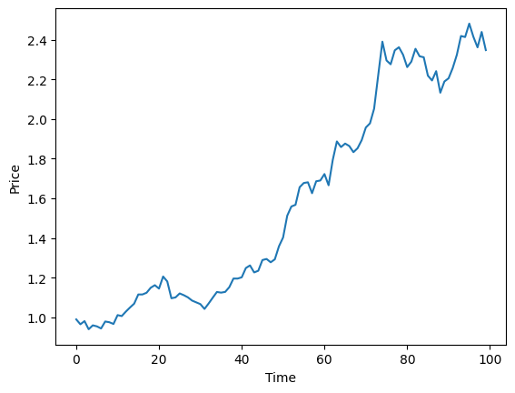

```python
R_1 = np.random.normal(1.01, 0.03, 100)
A_1 = np.cumprod(R_1)
P = A_1
plt.plot(P)
plt.xlabel('Time')
plt.ylabel('Price');
```

Trong trường hợp này, chúng ta hoàn toàn bị ảnh hưởng bởi sự biến động của tài sản đó, vì danh mục đầu tư của chúng ta hoàn toàn là tài sản đó.

### Trường hợp 2: Đầu tư vào Nhiều Tài sản Có Tương Quan

Trong trường hợp này, chúng ta mở rộng danh mục tài sản, nhưng vẫn có một lượng lớn tương quan giữa các lợi suất của các tài sản. Chúng ta mô phỏng điều này bằng cách mô phỏng các tài sản từ 2 đến N như tài sản 1 cộng với một số nhiễu.

```
Asset Volatilities
[np.float64(0.03129540422972072), np.float64(0.03334306174151843), np.float64(0.033203803345546325), np.float64(0.032188705663513326), np.float64(0.03274832824941648), np.float64(0.03339778103932711), np.float64(0.033185704388649866), np.float64(0.03242870879044401), np.float64(0.034012750360478176)…
Mean Asset Volatility
0.03287101573103376
Portfolio Volatility
0.03169776409500393
```

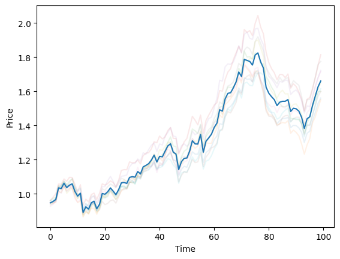

```python
N = 10

returns = np.zeros((N, 100))
assets = np.zeros((N, 100))

R_1 = np.random.normal(1.01, 0.03, 100)
returns[0] = R_1
assets[0] = np.cumprod(R_1)
plt.plot(assets[0], alpha=0.1)

for i in range(1, N):
    R_i = R_1 + np.random.normal(0.001, 0.01, 100)
    returns[i] = R_i
    assets[i] = np.cumprod(R_i)

    plt.plot(assets[i], alpha=0.1)

R_P = np.mean(returns, axis=0)
P = np.mean(assets, axis=0)
plt.plot(P)
plt.xlabel('Time')
plt.ylabel('Price');

print('Asset Volatilities')
print([np.std(R) for R in returns])
print('Mean Asset Volatility')
print(np.mean([np.std(R) for R in returns]))
print('Portfolio Volatility')
print(np.std(R_P))
```

Ở đây bạn có thể thấy danh mục đầu tư kèm theo tất cả các tài sản, các tài sản được vẽ mờ hơn. Điều quan trọng cần lưu ý là danh mục đầu tư trải qua tất cả các cú sốc giống như các tài sản, vì khi một tài sản tăng hoặc giảm, tất cả các tài sản khác cũng có khả năng như vậy. Đây là vấn đề với các tài sản có tương quan. Hãy cùng xem xét sự biến động của các tài sản và sự biến động của danh mục đầu tư.

Sự biến động trung bình của tài sản của chúng ta giống như sự biến động của danh mục đầu tư. Chúng ta không thu được lợi ích gì từ việc đặt nhiều cược hơn. Bạn có thể coi những lần cược có tương quan như là giống hệt với cược ban đầu. Nếu kết quả của cược thứ hai có tương quan với cược đầu tiên, thì thực sự bạn chỉ đang đặt cược giống nhau hai lần và bạn không giảm được sự biến động của mình.

### Trường hợp 3: Đầu tư vào nhiều tài sản không tương quan

Trong trường hợp này, chúng tôi độc lập tạo ra một loạt tài sản và xây dựng một danh mục đầu tư kết hợp tất cả chúng lại với nhau.

```
Asset Volatilities
[np.float64(0.029871325403783212), np.float64(0.0297910739560557), np.float64(0.029624427446312426), np.float64(0.02992588828641216), np.float64(0.028319885948721875), np.float64(0.03426974017203684), np.float64(0.03541848983540769), np.float64(0.030530147566203373), np.float64(0.028543667248112213)…
Mean Asset Volatility
0.030577646111010614
Portfolio Volatility
0.010137403517176935
```

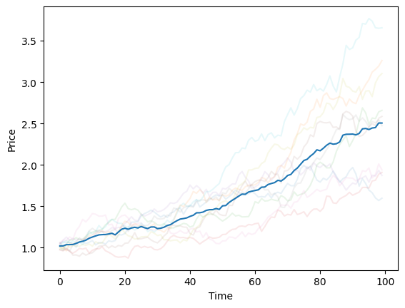

```python
N = 10

assets = np.zeros((N, 100))
returns = np.zeros((N, 100))

for i in range(N):
    R_i = np.random.normal(1.01, 0.03, 100)
    returns[i] = R_i
    assets[i] = np.cumprod(R_i)

    plt.plot(assets[i], alpha=0.1)

R_P = np.mean(returns, axis=0)
P = np.mean(assets, axis=0)
plt.plot(P)
plt.xlabel('Time')
plt.ylabel('Price');

print('Asset Volatilities')
print([np.std(R) for R in returns])
print('Mean Asset Volatility')
print(np.mean([np.std(R) for R in returns]))
print('Portfolio Volatility')
print(np.std(R_P))
```

Bây giờ chúng ta thấy lợi ích của việc đa dạng hóa. Việc nắm giữ nhiều tài sản không tương quan giúp làm mượt danh mục đầu tư của chúng ta. Khi một tài sản giảm giá, những tài sản khác không có khả năng giảm giá nhiều hơn, vì vậy những biến động cả lên và xuống thường nhỏ hơn nhiều. Càng nắm giữ nhiều tài sản, chúng ta càng giảm được sự biến động. Hãy kiểm tra điều đó.

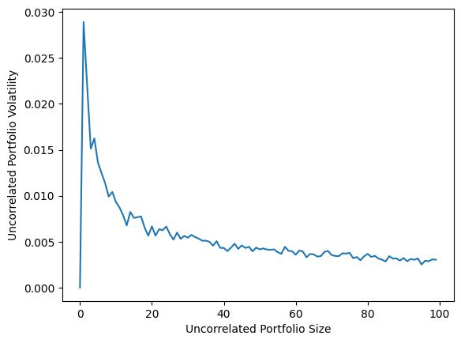

```python
portfolio_volatilities_by_size = np.zeros((100,1))

for N in range(1,100):

    assets = np.zeros((N, 100))
    returns = np.zeros((N, 100))

    for i in range(N):
        R_i = np.random.normal(1.01, 0.03, 100)
        returns[i] = R_i

    R_P = np.mean(returns, axis=0)

    portfolio_volatilities_by_size[N] = np.std(R_P)

plt.plot(portfolio_volatilities_by_size)
plt.xlabel('Uncorrelated Portfolio Size')
plt.ylabel('Uncorrelated Portfolio Volatility');
```

## Điều Cuối Cùng

Hãy đầu tư vào nhiều tài sản không tương quan càng nhiều càng tốt. Trong tài chính, điều này được gọi là đa dạng hóa. Nếu bạn có một mô hình định giá, hãy định giá mọi thứ và đầu tư theo đó. Khái niệm này được giải thích trong Bài Giảng Cổ Phiếu Long - Short.

## Hạn Chế Vốn

Do chi phí giao dịch, bạn cần có một số lượng vốn tối thiểu nhất định để đầu tư vào nhiều tài sản. Do đó, đôi khi bạn không thể đầu tư vào hàng trăm hoặc hàng nghìn tài sản. Trong trường hợp này, bạn vẫn nên cố gắng tối đa hóa quy mô danh mục đầu tư của mình, nhớ rằng nếu bạn có một danh mục đầu tư với kích thước 20, bạn vẫn có thể tìm được 20 tài sản tương quan tương đối thấp và điều đó vẫn tốt hơn là không có gì.

## Bây giờ Hãy Giải Thích Bằng Toán Học Thay Vì Hình Ảnh

Một trong những khía cạnh chính của lý thuyết danh mục đầu tư hiện đại là việc kết hợp nhiều tài sản vào một danh mục đầu tư có thể giảm thiểu rủi ro tổng thể của toàn bộ gói. Vì chúng ta đại diện cho độ biến động của một tài sản bằng độ lệch chuẩn của nó, chúng ta có thể dễ dàng chỉ ra điều này bằng toán học.

Giả sử rằng chúng ta có hai tài sản trong một danh mục đầu tư, $S_1$ và $S_2$, với trọng số $\omega_1$ và $\omega_2$ sao cho $\omega_1 + \omega_2 = 1$. Gọi danh mục đầu tư là $P$ và giả sử rằng $S_1$ và $S_2$ có trung bình và độ lệch chuẩn lần lượt là $\mu_1, \sigma_1$ và $\mu_2, \sigma_2$. Chúng ta có thể tính toán giá trị của $P$ một cách dễ dàng.

$$ P = \omega_1 S_1 + \omega_2 S_2 $$

Bây giờ, chúng ta đặt $\mu_P$ là lợi suất của danh mục đầu tư $P$. Thật đơn giản để tính toán lợi suất kỳ vọng của danh mục đầu tư này:

$$ E[\mu_P] = E[\omega_1 \mu_1 + \omega_2 \mu_2] = \omega_1 E[\mu_1] + \omega_2 E[\mu_2] $$

Như bạn có thể thấy, lợi suất kỳ vọng của toàn bộ danh mục đầu tư có thể được xác định trực tiếp bằng cách sử dụng lợi suất kỳ vọng của các tài sản *trong* danh mục đầu tư cũng như trọng số tương ứng của chúng. Tương tự, chúng ta có thể sử dụng các đặc điểm này để xác định rủi ro tổng thể của danh mục đầu tư, $\sigma_p$. Đầu tiên, chúng ta tính toán phương sai của danh mục đầu tư, $\sigma_p^2 = VAR[P]$. Sau đó, chúng ta nói rằng hệ số tương quan giữa $S_1$ và $S_2$ là $COR[S_1,S_2] = \frac{COV[S_1,S_2]}{\sigma_1\sigma_2} = \rho_{12}$. Các phép tính sau đó sẽ theo sau:

\begin{eqnarray} \sigma_p^2 &=& VAR[P] \\ &=& VAR[\omega_1 S_1 + \omega_2 S_2] \\ &=& VAR[\omega_1 S_1] + VAR[\omega_2 S_2] + COV[\omega_1 S_1,\omega_2 S_2] \\ &=& \omega_1^2 VAR[S_1] + \omega_2^2 VAR[S_2] + 2\omega_1\omega_2 COV[S_1,S_2] \\ &=& \omega_1^2 \sigma_1^2 + \omega_2^2 \sigma_2^2 + 2\rho_{12}\omega_1\omega_2\sigma_1\sigma_2 \end{eqnarray}

```python
stocks = np.array([100, 75])
mean_returns = np.array([4, 6])

r_12 = 0.20
cov_12 = r_12 * 0.05 * 0.08
covariance_matrix = np.array([[0.05**2,cov_12],[cov_12,0.08**2]])

weights = np.array([0.7, 0.3])

P = np.dot(weights, stocks.T)
```

Bây giờ chúng ta sẽ tính toán rủi ro tổng thể của danh mục đầu tư:

```python
var_p = np.dot(np.dot(weights, covariance_matrix), weights.T)
sigma_p = np.sqrt(var_p)
print("The overall risk of the portfolio is", sigma_p)
```

```
The overall risk of the portfolio is 0.04622769732530488
```

Bằng cách kết hợp các tài sản vào một danh mục, chúng ta đã có thể tạo ra một gói với mức rủi ro tổng thể thấp hơn so với từng tài sản riêng lẻ. Nếu chúng ta thêm nhiều tài sản vào danh mục, chúng ta có thể giảm thêm rủi ro so với bất kỳ tài sản riêng biệt nào.

## Lợi ích của các lần cược bổ sung

Chúng ta có thể mở rộng ý tưởng này sang một danh mục gồm $n$ chứng khoán một cách khá dễ dàng. Càng nhiều tài sản bạn đưa vào danh mục của mình, rủi ro tổng thể của bạn sẽ càng thấp. Đây là dạng tổng quát cho phương sai của danh mục đầu tư trong trường hợp bạn có $n$ tài sản:

$$ \sigma_p^2 = \sum_i \omega_i^2 \sigma_i^2 + \sum_i\sum_{j\neq i} \omega_i\omega_j\sigma_i\sigma_j\rho_{ij}, \ i, j \in \lbrace 1,\ldots, n\rbrace $$

Các lợi ích này có thể được tăng cường bằng cách đảm bảo rằng các tài sản của bạn độc lập với nhau. Khi hai tài sản độc lập, chúng không tương quan, tức là $\rho_{ij}=0$. Sự tương quan giữa mỗi cặp tài sản đóng một vai trò rất quan trọng trong các phép tính của chúng ta để xác định phương sai của một danh mục đầu tư. Sự tương quan cao hơn giữa các tài sản, thì chúng ta cần phải bao gồm nhiều tài sản hơn để giảm rủi ro của mình với một lượng tương đương.

```python
stocks = np.array([230, 176, 192, 105])
mean_returns = np.array([2.0, 3.5, 7.5, 5.0])
std_dev = np.array([0.05, 0.07, 0.11, 0.09])
weights = np.array([0.35, 0.30, 0.15, 0.20])


r_12 = 0.2
r_13 = 0.08
r_14 = 0.1
r_23 = 0.6
r_24 = 0.4
r_34 = 0.8
covariance_matrix = np.array([[0.05**2, r_12 * 0.05 * 0.07, r_13 * 0.05 * 0.11, r_14 * 0.05 * 0.09],
                             [r_12 * 0.05 * 0.07, 0.07**2, r_23 * 0.07 * 0.11, r_24 * 0.07 * 0.09],
                             [r_13 * 0.05 * 0.11, r_23 * 0.07 * 0.11, 0.11**2, r_34 * 0.11 * 0.09],
                             [r_14 * 0.05 * 0.09, r_24 * 0.07 * 0.09, r_34 * 0.11 * 0.09, 0.09**2]])
```

```python
var_p = np.dot(np.dot(weights, covariance_matrix), weights.T)
sigma_p = np.sqrt(var_p)
print("The overall risk of the portfolio is:", sigma_p)
```

```
The overall risk of the portfolio is: 0.052849787132967715
```

Bây giờ hãy giả định rằng các mối tương quan giữa tất cả các tài sản này là $0$, và chúng đều độc lập theo từng cặp. Chúng ta sẽ giả định rằng mọi thứ khác vẫn giữ nguyên như trước. Sử dụng các tính toán của chúng ta cho rủi ro của danh mục đầu tư, chúng ta có:

```python
covariance_matrix = np.array([[0.05**2, 0, 0, 0],
                             [0, 0.07**2, 0, 0],
                             [0, 0, 0.11**2, 0],
                             [0, 0, 0, 0.09**2]])
var_p = np.dot(np.dot(weights, covariance_matrix), weights.T).flatten()
sigma_p = np.sqrt(var_p)
print("The overall risk of the portfolio is:", sigma_p)
```

```
The overall risk of the portfolio is: [0.03665379]
```

Chúng tôi đã có thể giảm đáng kể rủi ro tổng thể của danh mục đầu tư chỉ bằng cách chọn các tài sản độc lập với nhau. Mặc dù bạn vẫn có thể giảm rủi ro của mình bằng cách thêm các tài sản có tương quan, nhưng bạn sẽ cần phải thêm một số lượng lớn hơn các tài sản để đạt được hiệu ứng tương tự như với các tài sản không tương quan.

Hàm sau đây sẽ cho phép bạn tạo ngẫu nhiên một danh mục đầu tư có chiều dài tùy ý:

```python
# Generate an almost entirely random portfolio
# Only constraint is that an asset's variance
def generate_portfolio(n = 5):
    assets = np.random.normal(100, 20, n)
    weights = np.random.uniform(0, 1, n)
    weights = weights/sum(weights)
    returns = np.random.normal(5, 2, n) # Say that 5 is the average return for our assets
    # Generate covariance matrix for assets
    cov_matrix = np.ndarray(shape = (n, n))
    std_dev = np.zeros(n)
    for i in range(n):
        for j in range(i + 1):
            if j == i:
                std_dev[i] = returns[i]/100
                cov_matrix[i][j] = std_dev[i]**2
            else:
                cov_matrix[i][j] = np.random.uniform(-1, 1)
                cov_matrix[j][i] = cov_matrix[i][j]
    # Ensures that the covariance matrix is symmetric
    # Serves the double purpose of squaring the volatility (already present in the matrix) so we get variance
    return weights, assets, returns, std_dev, cov_matrix
```

Chúng ta bây giờ có thể sử dụng hàm này để tạo ngẫu nhiên một tập hợp tài sản, mỗi tài sản có một tỷ suất sinh lợi khác nhau, cũng như ma trận hiệp phương sai của các tài sản.

```python
w, S, mu, sigma, cov = generate_portfolio(6)
print("Weights:\n", w)
print("Assets:\n", S)
print("Returns:\n", mu)
print("Volatilities:\n", sigma)
print("\nCovariance Matrix:\n", cov)
```

```
Weights:
 [0.1701843  0.0476093  0.01426263 0.30616213 0.1600367  0.30174495]
Assets:
 [116.56881722  87.97793382  88.13300165 118.14251296 101.8935891
  97.82690548]
Returns:
 [ 3.05930791  6.88534582  7.47784013  7.05540847  3.17034939 10.88036796]
Volatilities:
 [0.03059308 0.06885346 0.0747784  0.07055408 0.03170349 0.10880368]

Covariance Matrix:
 [[ 9.35936486e-04 -4.44800155e-01  7.30492469e-01  7.03094464e-01
   7.84055014e-01  7.35403239e-01]
 [-4.44800155e-01  4.74079871e-03 -2.68236249e-01 -2.89874923e-01
  -9.33609724e-01 -6.40282150e-01]
 [ 7.30492469e-01 -2.68236249e-01  5.59180929e-03 -9.46704610e-01
   3.42733382e-01  4.40471393e-01]
 [ 7.03094464e-01 -2.89874923e-01 -9.46704610e-01  4.97787887e-03
   8.83294688e-02  1.44565492e-01]
 [ 7.84055014e-01 -9.33609724e-01  3.42733382e-01  8.83294688e-02
   1.00511152e-03 -2.78771211e-01]
 [ 7.35403239e-01 -6.40282150e-01  4.40471393e-01  1.44565492e-01
  -2.78771211e-01  1.18382407e-02]]
```

Và bây giờ chúng ta có thể dễ dàng thực hiện các phép tính giống như trước đây để xác định giá trị tổng thể của danh mục đầu tư và rủi ro.

```python
P = np.dot(w, S)
var_p = np.dot(np.dot(w, cov), w.T)
sigma_p = np.sqrt(abs(var_p))
print("Portfolio Value:", P)
print("Portfolio Volatility:", sigma_p)
```

```
Portfolio Value: 107.28000968510355
Portfolio Volatility: 0.3918496135111516
```

Hãy nhớ rằng nếu bạn quyết định thay đổi chức năng này, bạn phải bao gồm một số biện pháp bảo vệ để đảm bảo rằng lợi suất cao hơn luôn tương ứng với độ biến động cao hơn. Đây là một trong những giả định cốt lõi của lý thuyết danh mục đầu tư và, mặc dù không liên quan ở đây do các giá trị trọng số tùy ý của chúng ta, nhưng nó rất quan trọng trong việc tính toán các trọng số của một danh mục đầu tư tối ưu.

*Lưu ý: Tài liệu này mang tính chất chia sẻ kiến thức khoa học dữ liệu. Các mã chứng khoán xuất hiện trong tài liệu chỉ mang tính chất minh hoạ, không khuyến nghị đầu tư. Chúng tôi không chịu trách nhiệm trước mọi rủi ro nào do sử dụng tài liệu này.*